# Análisis Exploratorio de Datos Financieros para la Identificación de Estructuras Latentes en las Acciones de Microsoft (2000 - 2026)

Observemos ahora el gráfico con bandas de confianza:

```
Cobertura empírica IC 68%: 70.3% (esperado ~68%)
Cobertura empírica IC 95%: 94.2% (esperado ~95%)
```

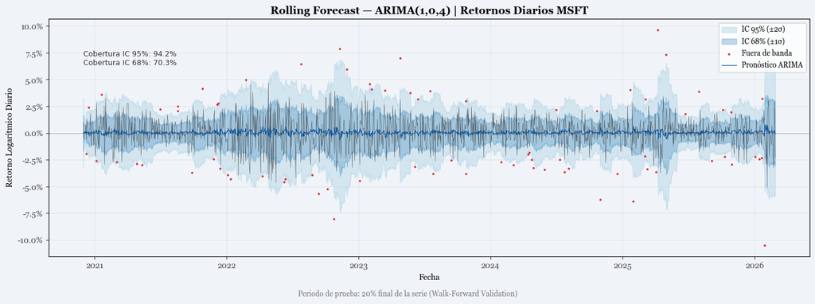

```python
import numpy as np
import pandas as pd
import matplotlib.pyplot as plt
import matplotlib.patches as mpatches
from scipy.ndimage import uniform_filter1d

# Desviación estándar móvil de los errores (proxy de incertidumbre local)
window_sd  = 21  # ventana de 1 mes
roll_errors = actual_vals - forecast_vals

sd_local = (
    pd.Series(roll_errors)
    .rolling(window=window_sd, min_periods=1)
    .std()
    .fillna(pd.Series(roll_errors).std())
    .values
)

# Fechas del periodo de test
test_dates_v = returns_clean.index[train_size:]

viz_df = pd.DataFrame({
    'Date':     test_dates_v,
    'Real':     actual_vals,
    'Pred':     forecast_vals,
    'SD_local': sd_local
})

# Bandas ±1σ y ±2σ
viz_df['up2'] = viz_df['Pred'] + 2.0 * viz_df['SD_local']
viz_df['lo2'] = viz_df['Pred'] - 2.0 * viz_df['SD_local']
viz_df['up1'] = viz_df['Pred'] + 1.0 * viz_df['SD_local']
viz_df['lo1'] = viz_df['Pred'] - 1.0 * viz_df['SD_local']

# Flag: retorno real dentro/fuera de banda 95%
viz_df['dentro'] = (viz_df['Real'] >= viz_df['lo2']) & (viz_df['Real'] <= viz_df['up2'])

# Cobertura empírica
cobertura_95 = viz_df['dentro'].mean() * 100
cobertura_68 = ((viz_df['Real'] >= viz_df['lo1']) &
                (viz_df['Real'] <= viz_df['up1'])).mean() * 100

print(f"Cobertura empírica IC 68%: {cobertura_68:.1f}% (esperado ~68%)")
print(f"Cobertura empírica IC 95%: {cobertura_95:.1f}% (esperado ~95%)")

# Gráfico
fig, ax = plt.subplots(figsize=(14, 5))
fig.patch.set_facecolor('#f0f4f8')
ax.set_facecolor('#f0f4f8')

# Banda ±2σ (IC ~95%)
ax.fill_between(viz_df['Date'], viz_df['lo2'], viz_df['up2'],
                color='#9ecae1', alpha=0.35, label='IC 95% (±2σ)')

# Banda ±1σ (IC ~68%)
ax.fill_between(viz_df['Date'], viz_df['lo1'], viz_df['up1'],
                color='#3182bd', alpha=0.30, label='IC 68% (±1σ)')

# Retorno real dentro de banda
dentro  = viz_df[viz_df['dentro']]
fuera   = viz_df[~viz_df['dentro']]

ax.plot(dentro['Date'], dentro['Real'],
        color='#2c2c2c', linewidth=0.4, alpha=0.75)

# Puntos fuera de banda en rojo
ax.scatter(fuera['Date'], fuera['Real'],
           color='#d62728', s=3, alpha=0.85, label='Fuera de banda', zorder=5)

# Línea de pronóstico
ax.plot(viz_df['Date'], viz_df['Pred'],
        color='#08519c', linewidth=0.75, label='Pronóstico ARIMA')

# Línea de referencia en 0
ax.axhline(0, linestyle='--', color='#555555', linewidth=0.4)

# Anotación de cobertura
ax.annotate(
    f"Cobertura IC 95%: {cobertura_95:.1f}%\nCobertura IC 68%: {cobertura_68:.1f}%",
    xy=(viz_df['Date'].iloc[0], viz_df['up2'].max() * 0.92),
    fontsize=9, color='#333333', family='sans-serif'
)

# Formato ejes
ax.yaxis.set_major_formatter(plt.FuncFormatter(lambda x, _: f'{x:.1%}'))
ax.grid(axis='both', color='#d0d8e4', linewidth=0.4)
ax.tick_params(colors='#444444')

# Títulos y leyenda
ax.set_title(f"Rolling Forecast — ARIMA({best_p},0,{best_q}) | Retornos Diarios MSFT",
             fontsize=13, fontweight='bold')
ax.set_xlabel("Fecha")
ax.set_ylabel("Retorno Logarítmico Diario")
fig.text(0.5, -0.02,
         "Periodo de prueba: 20% final de la serie (Walk-Forward Validation)",
         ha='center', fontsize=9, color='#777777')

ax.legend(loc='upper right', fontsize=9)
plt.tight_layout()
plt.show()
```

- La **línea azul oscura** representa el pronóstico de la media condicional $\hat{r}_t$ del modelo ARIMA. En retornos financieros esta línea oscilará cerca de cero, lo cual es correcto: el retorno esperado diario de un activo eficiente es próximo a su media histórica (~0.03%).
- Las **bandas azules** representan el intervalo de confianza construido a partir de la desviación estándar local de los errores (ventana móvil de 21 días). La banda interior corresponde a ±1σ (~68%) y la exterior a ±2σ (~95%).
- Los **puntos rojos** son días donde el retorno real quedó fuera de la banda del 95%, es decir, eventos extremos que el modelo no anticipó. La frecuencia de estos puntos frente al 5% teórico indica si el modelo subestima o sobestima el riesgo.